# GCA1 - VR-based Treatment of Autism

Ruth Dooley, Diego Morenza

**GitHub:** https://github.com/RuthDooley/2025_DAIE_ICA_DMRD

# Table of Contents

1. Abstract
2. Introduction
3. Method
4. Results
5. Discussion
6. References

# Abstract

## Aim and Rationale

The aim of this study is to evaluate the effectiveness of Virtual Reality (VR) and Cognitive Behavioral Therapy (CBT) to decrease the severity of autistic traits. The Autism Spectrum Quotient (AQ) was used to self capture the severity of each trait before and after the trail.

## Participants and Setting

300 participants between the ages of 12 - 40 years old were randomly assigned to to one of the three subject groups CBT, VR Therapy and Control. The individuals underwent 12 weeks of their respective treatment.

```r
data <- read.csv("CA1_Autism_VR_Study_Data_Final_Dec.csv")

head(data)
```

|  | ID | Group | Gender | P1_Pre_Score | P2_Post_Score | Change_Score |
| --- | --- | --- | --- | --- | --- | --- |
| 1 | 1 | Control | F | 45 | 37 | 8 |
| 2 | 2 | Control | F | 47 | 50 | -3 |
| 3 | 3 | Control | M | 48 | 46 | 2 |
| 4 | 4 | Control | F | 45 | 43 | 2 |
| 5 | 5 | Control | F | 45 | 47 | -2 |
| 6 | 6 | Control | F | 41 | 47 | -6 |

```r
colnames(data)
```

```
[1] "ID"            "Group"         "Gender"        "P1_Pre_Score"  "P2_Post_Score"
[6] "Change_Score"
```

```r
# Number of participants
cat("Dimensions:", dim(data), "\n")
```

```
Dimensions: 300 6
```

## Findings/Implications

# Introduction

## Topic and Context

Autism Spectrum Disorder (ASD) is a complex neurodevelopmental condition characterised by a wide range of social, communication, and behavioral differences. Outlined in the Diagnostic and Statistical Manual of Mental Disorders (DSM-5), the diagnostic criteria is centred around “persistent deficits in social communication and social interaction” and “restricted, repetitive patterns of behavior, interests, or activities”. The Autism Spectrum Quotient (AQ) is a self report questionnaire designed to capture the complexity of measuring autistic traits across multiple subscales.

## Rationale

Those exhibiting traits of autism may engage in therapy to reduce the severity of such autistic traits. Understanding the differences in effectiveness of VR therapy, CBT vs no treatment to the AQ score can inform medical professionals to deliver the most appropriate form of treatment for the individual.

## Hypothesis

**Hypothesis 1 (Comparison Across All Three Groups):**

- H₀: The three groups (CBT, VR, Control) have equal mean Change_Score.
- H₁: At least one group has a different mean Change_Score.

**Hypothesis 2 (Any Therapy vs Control):**

- H₀: The mean Change_Score for participants receiving therapy (CBT or VR) is equal to the mean for the Control group.
- H₁: Participants receiving therapy show greater improvement than the Control group.

**Hypothesis 3 (CBT vs VR):**

- H₀: The mean improvement (Change_Score) is the same for the CBT and VR groups.
- H₁: The mean improvement differs between CBT and VR.

# Method

## Participants

- **CBT:** n=100 (M=53, F=47)
- **VR:** n=100 (M=48, F=52)
- **Control:** n=100 (M=59, F=41)

```r
# Total gender distribution
table(data$Gender)
```

```
  F   M
140 160
```

```r
# Group distribution
table(data$Group)
```

```
    CBT Control      VR
    100     100     100
```

```r
# Gender distribution by group
print(table(data$Gender[data$Group == "CBT"]))
```

```
 F  M
47 53
```

```r
print(table(data$Gender[data$Group == "VR"]))
```

```
 F  M
52 48
```

```r
print(table(data$Gender[data$Group == "Control"]))
```

```
 F  M
41 59
```

## Design

The independent variable was the type of therapy delivered (CBT, VR, or Control), and the dependent variable was the change in AQ score comparing pre-treatment to post-treatment.

## Materials

**Autism Spectrum Quotient (AQ):** The AQ is a 50-item self report questionnaire that measures autistic traits, where the higher the participent score, the more pronounced the autistic traits of that individual.

**VR Equipment and Therapy:** VR technology can be used to create immersive experiences suitable for users to practice social interactions and confront challenges in controlled environments.

**CBT Sessions:** CBT is a therapy technique that is used to support individuals on the autism spectrum by helping individuals manage and reframe challenges related to social interactions and emotional regulation.

## Procedure

1. All participants completed the AQ to establish initial pre-treatment score (P1_Pre_Score).
2. Participants engaged in their assigned therapy for the 12 week period.
3. All participants repeated the AQ (P2_Post_Score).
4. Change_Score = P1_Pre_Score - P2_Post_Score. For this study, a positive change score indicates improvement (reduction in the severity autistic traits).
5. Data validation and cleaning:

```r
# Check for missing data
cat("Total missing values:", sum(is.na(data)), "\n")
```

```
Total missing values: 0
```

```r
cat("Total cases:", sum(complete.cases(data)), "\n")
```

```
Total cases: 300
```

```r
# Verify AQ scores are within valid range (0-50)
cat("P1_Pre_Score range:", range(data$P1_Pre_Score), "\n")
```

```
P1_Pre_Score range: 32 50
```

```r
cat("P2_Post_Score range:", range(data$P2_Post_Score), "\n")
```

```
P2_Post_Score range: 20 50
```

```r
# Verify AQ scores are within valid range (0-50)
cat("P1_Pre_Score range:", range(data$P1_Pre_Score), "\n")
```

```
P1_Pre_Score range: 32 50
```

```r
cat("P2_Post_Score range:", range(data$P2_Post_Score), "\n")
```

```
P2_Post_Score range: 20 50
```

```r
# Check for duplicate participant IDs
duplicates <- sum(duplicated(data$ID))
cat("Duplicate IDs found:", duplicates, "\n")
```

```
Duplicate IDs found: 0
```

# Results

## Descriptive Statistics

```r
library(dplyr)
library(kableExtra)

# Descriptive statistics were calculated to get an overview of group characteristics and get an initial understanding of the dataset and effects.
desc_stats <- data %>%
  group_by(Group) %>%
  summarise(
    N = n(),
    Mean = round(mean(Change_Score), 2),
    SD = round(sd(Change_Score), 2),
    Median = median(Change_Score),
    Min = min(Change_Score),
    Max = max(Change_Score)
  )

# Library to give the table a header
desc_stats %>%
  kable(
    caption = "Table 1: Descriptive Statistics of Change_Score by Treatment Group",
    digits = 2
  ) %>%
  kable_styling(full_width = TRUE)
```

Table 1: Descriptive Statistics of Change_Score by Treatment Group

| Group | N | Mean | SD | Median | Min | Max |
| --- | --- | --- | --- | --- | --- | --- |
| CBT | 100 | 10.09 | 4.41 | 10 | 1 | 21 |
| Control | 100 | 0.60 | 3.78 | 0 | -7 | 8 |
| VR | 100 | 18.62 | 4.95 | 18 | 6 | 30 |

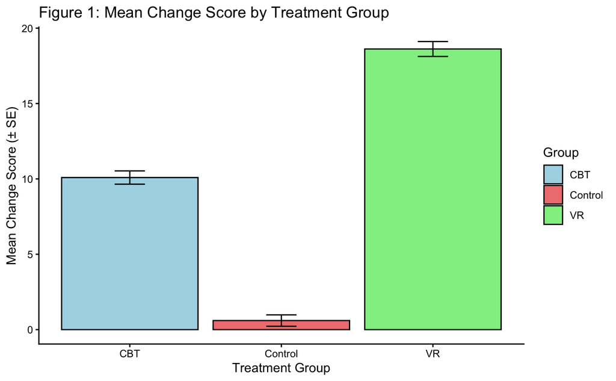

```r
library(ggplot2)

# Bar chart visually desribing the mean chang eof score by treatment group
summary_stats <- data %>%
  group_by(Group) %>%
  summarise(
    Mean = mean(Change_Score),
    SD = sd(Change_Score),
    SE = SD / sqrt(n())
  )

ggplot(summary_stats, aes(x = Group, y = Mean, fill = Group)) +
  geom_bar(stat = "identity", color = "black") +
  geom_errorbar(aes(ymin = Mean - SE, ymax = Mean + SE), width = 0.2) +
  labs(title = "Figure 1: Mean Change Score by Treatment Group",
       x = "Treatment Group",
       y = "Mean Change Score (± SE)") +
  scale_fill_manual(values = c("lightblue", "lightcoral", "lightgreen")) +
  theme_classic()
```

Descriptive analysis in Table 1 and Figure 1 reveals:

- VR: Highest mean improvement (M=18.62, SD=4.95), with scores ranging 6 - 30.
- CBT: Moderate improvement (M=10.09, SD=4.41), with scores ranging 1 - 21.
- Control: Negligible change (M=0.6 SD=3.78), with scores ranging -7 - 8.

There is a positive improvement in results for VR and CBT therapy. Control results suggest that non intervention likely does not decrease the severity of the individuals autistic traits.

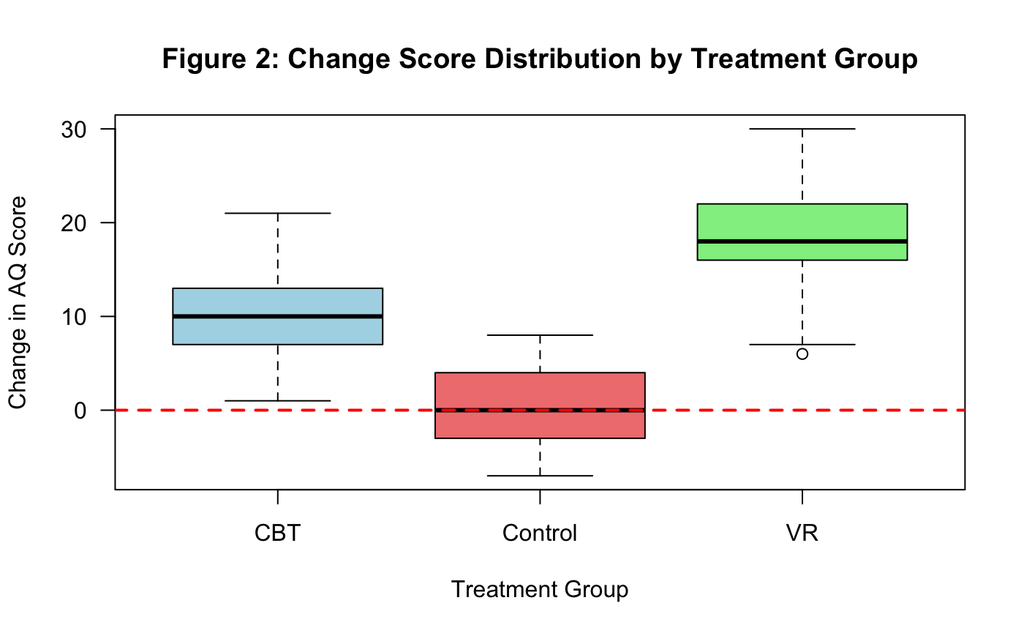

```r
# Distribution of Change_Score by group
boxplot(Change_Score ~ Group, data = data,
        main = "Figure 2: Change Score Distribution by Treatment Group",
        xlab = "Treatment Group",
        ylab = "Change in AQ Score",
        col = c("lightblue", "lightcoral", "lightgreen"),
        border = "black",
        las = 1)

# Horizontal line at zero
abline(h = 0, col = "red", lty = 2, lwd = 2)
```

Figure 2 illustrates the median of VR~18, CBT~10, Control~0. 1 outlier (beyond 1.5 times the interquartile range) is observed.

## Inferential Statistics

The statistical assumptions of normality, homogeneity of variance, and absence of extreme outliers were tested to ensure the data set met the assumptions of parametric statistical tests.

```r
par(mfrow = c(1, 3))

qqnorm(data$Change_Score[data$Group == "CBT"], main = "Figure 3a. CBT Group Q-Q Plot")
qqline(data$Change_Score[data$Group == "CBT"], col = "red")
```

```r
qqnorm(data$Change_Score[data$Group == "VR"], main = "Figure 3b. VR Group Q-Q Plot")
qqline(data$Change_Score[data$Group == "VR"], col = "red")
```

```r
qqnorm(data$Change_Score[data$Group == "Control"], main = "Figure 3c. Control Group Q-Q Plot")
qqline(data$Change_Score[data$Group == "Control"], col = "red")
```

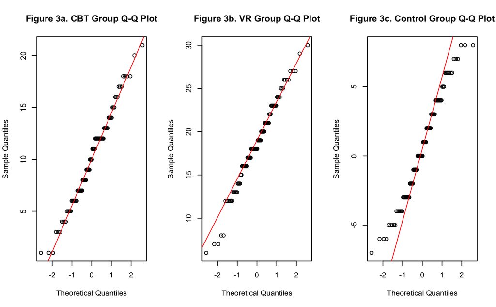

```r
par(mfrow = c(1, 1))
```

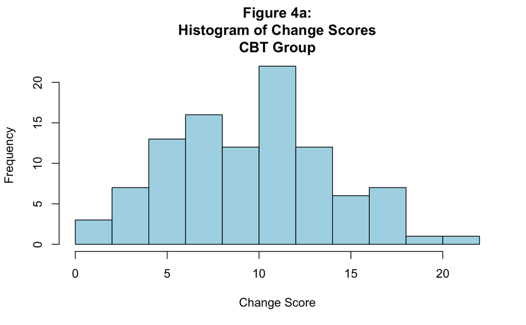

```r
# Assessment of normality using histograms
hist(data$Change_Score[data$Group == "CBT"],
     main = "Figure 4a:\nHistogram of Change Scores\nCBT Group",
     xlab = "Change Score",
     col = "lightblue",
     border = "black")
```

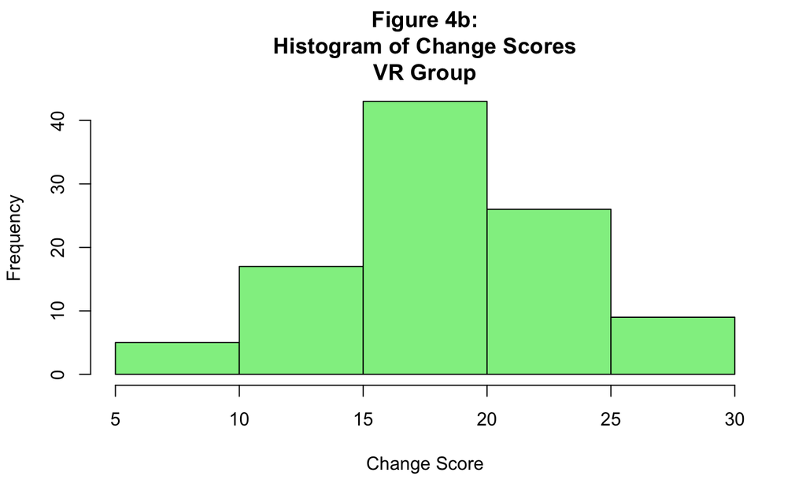

```r
hist(data$Change_Score[data$Group == "VR"],
     main = "Figure 4b:\nHistogram of Change Scores\nVR Group",
     xlab = "Change Score",
     col = "lightgreen",
     border = "black")
```

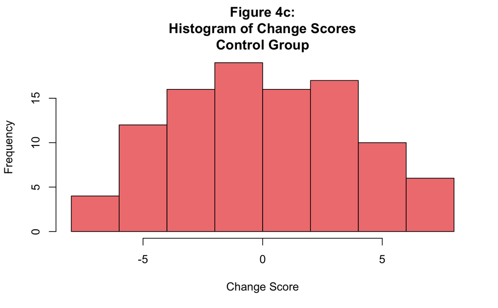

```r
hist(data$Change_Score[data$Group == "Control"],
     main = "Figure 4c:\nHistogram of Change Scores\nControl Group",
     xlab = "Change Score",
     col = "lightcoral",
     border = "black")
```

```r
# Using the Shapiro-Wilk statistical test, the p-value of the data was measured. For each group if p > 0.05, data are considered normally distributed
cat("CBT Group:\n")
```

```
CBT Group:
```

```r
print(shapiro.test(data$Change_Score[data$Group == "CBT"]))
```

```
    Shapiro-Wilk normality test

data:  data$Change_Score[data$Group == "CBT"]
W = 0.98389, p-value = 0.2634
```

```r
cat("\nVR Group:\n")
```

```
VR Group:
```

```r
print(shapiro.test(data$Change_Score[data$Group == "VR"]))
```

```
    Shapiro-Wilk normality test

data:  data$Change_Score[data$Group == "VR"]
W = 0.98496, p-value = 0.3156
```

```r
cat("\nControl Group:\n")
```

```
Control Group:
```

```r
print(shapiro.test(data$Change_Score[data$Group == "Control"]))
```

```
    Shapiro-Wilk normality test

data:  data$Change_Score[data$Group == "Control"]
W = 0.9728, p-value = 0.03633
```

CBT and VR groups are normally distributed p = 0.2634 and p = 0.3156 > 0.05 respectively. The Control group p = 0.0.03633 and < 0.05 suggesting deviation from normality.

```r
sd_cbt <- sd(data$Change_Score[data$Group == "CBT"])
sd_vr <- sd(data$Change_Score[data$Group == "VR"])
sd_control <- sd(data$Change_Score[data$Group == "Control"])

cat("Variances:\n")
```

```
Variances:
```

```r
cat("CBT:", round(var(data$Change_Score[data$Group == "CBT"]), 2), "\n")
```

```
CBT: 19.42
```

```r
cat("VR:", round(var(data$Change_Score[data$Group == "VR"]), 2), "\n")
```

```
VR: 24.48
```

```r
cat("Control:", round(var(data$Change_Score[data$Group == "Control"]), 2), "\n\n")
```

```
Control: 14.26
```

```r
cat("Standard Deviations:\n")
```

```
Standard Deviations:
```

```r
cat("CBT:", round(sd_cbt, 2), "\n")
```

```
CBT: 4.41
```

```r
cat("VR:", round(sd_vr, 2), "\n")
```

```
VR: 4.95
```

```r
cat("Control:", round(sd_control, 2), "\n")
```

```
Control: 3.78
```

```r
cat("\nRatio of largest to smallest SD:", round(max(sd_cbt, sd_vr, sd_control) / min(sd_cbt, sd_vr, sd_control), 2), "\n")
```

```
Ratio of largest to smallest SD: 1.31
```

Outlier detection tested numerically using the interquartile range confirming visualisation in Figure 2.

```r
outliers <- function(x) {
  Q1 <- quantile(x, 0.25)
  Q3 <- quantile(x, 0.75)
  IQR_val <- Q3 - Q1
  lower <- Q1 - 1.5 * IQR_val
  upper <- Q3 + 1.5 * IQR_val
  sum(x < lower | x > upper)
}
cat("CBT:", outliers(data$Change_Score[data$Group == "CBT"]), "\n")
```

```
CBT: 0
```

```r
cat("VR:", outliers(data$Change_Score[data$Group == "VR"]), "\n")
```

```
VR: 1
```

```r
cat("Control:", outliers(data$Change_Score[data$Group == "Control"]), "\n")
```

```
Control: 0
```

**Statistical Assumption Summary:** * The CBT and VR groups are normally distributed. While the Control group shows a minor deviation, the large sample size and robustness of ANOVA allow for valid inference. The visual assessment of the Control group data Figure 3 and 4, show only minor deviations. * Variances are approximately equal across groups. * 1 outlier was detected, but does not meaningfully affect the distribution.

## Statistical Tests

```r
# Hypothesis 1 (Comparison Across All Three Groups):
# H₀: The three groups (CBT, VR, Control) have equal mean Change_Score.
# H₁: At least one group has a different mean Change_Score.

mean_cbt <- mean(data$Change_Score[data$Group == "CBT"], na.rm = TRUE)
mean_vr <- mean(data$Change_Score[data$Group == "VR"], na.rm = TRUE)
mean_control <- mean(data$Change_Score[data$Group == "Control"], na.rm = TRUE)

cat("Mean Change_Score by Group:\n")
```

```
Mean Change_Score by Group:
```

```r
cat("CBT:", round(mean_cbt, 3), "\n")
```

```
CBT: 10.09
```

```r
cat("VR:", round(mean_vr, 3), "\n")
```

```
VR: 18.62
```

```r
cat("Control:", round(mean_control, 3), "\n")
```

```
Control: 0.6
```

```r
# Hypothesis 2 (Any Therapy vs Control):
# H₀: The mean Change_Score for participants receiving therapy (CBT or VR) is equal to the mean for the Control group.
# H₁: Participants receiving therapy show greater improvement than the Control group.

# General therapy group combining VR and CBT results
data$TherapyGroup <- ifelse(data$Group == "Control", "Control", "Therapy")

cat("Distribution of TherapyGroup:\n")
```

```
Distribution of TherapyGroup:
```

```r
print(table(data$TherapyGroup))
```

```
Control Therapy
    100     200
```

```r
# Calculate mean Change_Score for Therapy vs Control
mean_therapy <- mean(data$Change_Score[data$TherapyGroup == "Therapy"], na.rm = TRUE)
mean_control_2 <- mean(data$Change_Score[data$TherapyGroup == "Control"], na.rm = TRUE)

cat("\nMean Change_Score:\n")
```

```
Mean Change_Score:
```

```r
cat("Therapy (CBT + VR):", round(mean_therapy, 3), "\n")
```

```
Therapy (CBT + VR): 14.355
```

```r
cat("Control:", round(mean_control_2, 3), "\n")
```

```
Control: 0.6
```

```r
# Hypothesis 3 (CBT vs VR):
# H₀: The mean improvement (Change_Score) is the same for the CBT and VR groups.
# H₁: The mean improvement differs between CBT and VR.

# CBT vs VR groups
cat("Distribution of CBT and VR Groups:\n")
```

```
Distribution of CBT and VR Groups:
```

```r
print(table(data$Group[data$Group != "Control"]))
```

```
CBT  VR
100 100
```

```r
# Calculate mean Change_Score for CBT vs VR
mean_cbt_3 <- mean(data$Change_Score[data$Group == "CBT"], na.rm = TRUE)
mean_vr_3 <- mean(data$Change_Score[data$Group == "VR"], na.rm = TRUE)

cat("\nMean Change_Score:\n")
```

```
Mean Change_Score:
```

```r
cat("CBT:", round(mean_cbt_3, 3), "\n")
```

```
CBT: 10.09
```

```r
cat("VR:", round(mean_vr_3, 3), "\n")
```

```
VR: 18.62
```

```r
cat("\nDifference (VR - CBT):", round(mean_vr_3 - mean_cbt_3, 3), "\n")
```

```
Difference (VR - CBT): 8.53
```

## Magnitude and Direction of Results

To estimate the true population mean improvement a 95% confidence interval was calculated with CBT and VR groups.

```r
group <- "CBT"

values <- data$Change_Score[data$Group == group]

mean_val <- mean(values)
sd_val <- sd(values)
n <- length(values)

se <- sd_val / sqrt(n)
lower <- mean_val - 1.96 * se
upper <- mean_val + 1.96 * se

cat("95% Confidence Interval for", group, ":\n")
```

```
95% Confidence Interval for CBT :
```

```r
cat("Mean =", round(mean_val, 2), "\n")
```

```
Mean = 10.09
```

```r
cat("CI =", round(lower, 2), "to", round(upper, 2), "\n")
```

```
CI = 9.23 to 10.95
```

```r
group <- "VR"

values <- data$Change_Score[data$Group == group]

mean_val <- mean(values)
sd_val <- sd(values)
n <- length(values)

se <- sd_val / sqrt(n)
lower <- mean_val - 1.96 * se
upper <- mean_val + 1.96 * se

cat("95% Confidence Interval for", group, ":\n")
```

```
95% Confidence Interval for VR :
```

```r
cat("Mean =", round(mean_val, 2), "\n")
```

```
Mean = 18.62
```

```r
cat("CI =", round(lower, 2), "to", round(upper, 2), "\n")
```

```
CI = 17.65 to 19.59
```

# Discussion

## Findings and Relation to Hypothesis

The study examined whether CBT and VR therapy reduced autistic traits compared to a control group.

H1: The groups differed in improvement, VR showed the greatest reduction in AQ scores, then CBT. The control showing almost no change.

H2: Both therapy groups improved substantially more than the control, supporting the effectiveness of intervention over no treatment.

H3: VR outperformed CBT; VR may provide greater therapeutic benefit.

## Limitations

- The overall gender distribution (M=160, F=140) varied from the intended equal distribution (M=150, F=150). Adequate gender representation is prferable.
- Slight deviation from normality in the control group (p=0.03633).
- 1 outlier detected in the VR group.
- The study analysis the effects of treatment over a 12-week intervention period. Future research could determine the effectiveness of these treatments over time.
- Exact age data were not recorded. Future studies could explore age-related moderators of treatment response.

# References

1. American Psychiatric Association. (2013). *Diagnostic and statistical manual of mental disorders* (5th ed.). American Psychiatric Publishing.
2. Lord, C., Elsabbagh, M., Baird, G., & Veenstra-Vanderweele, J. (2018). Autism spectrum disorder. *The Lancet, 392*(10146), 508–520.
3. Baron-Cohen, S., Wheelwright, S., Skinner, R., Martin, J., & Clubley, E. (2001). The Autism-Spectrum Quotient (AQ): Evidence from Asperger syndrome/high-functioning autism, males and females, scientists and mathematicians. *Journal of Autism and Developmental Disorders, 31*(1), 5–17.